# Online News

Analysing online news from german media outlets

Franziska Löw

2019-03-14

# Visits

News sources used for the analysis including their respective number of articles and readers measured as Visits. As no advertising is permitted on the Tagesschau.de website in accordance with the Interstate Broadcasting Treaty, public data is difficult to find or compare.

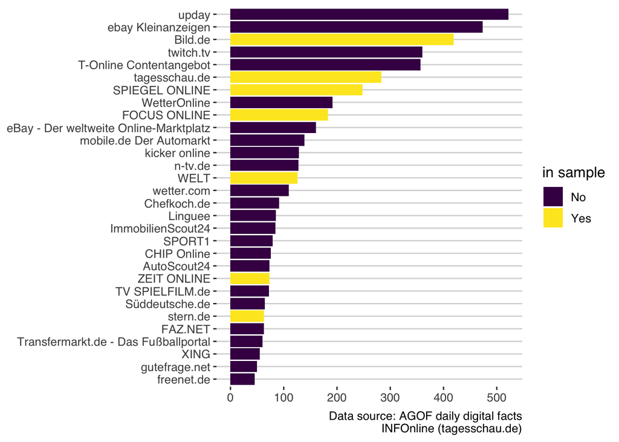

# Article content

## Number of articles by medium

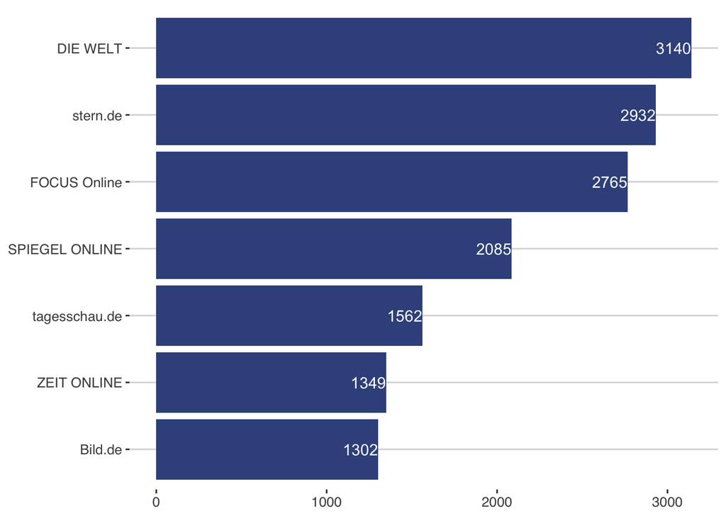

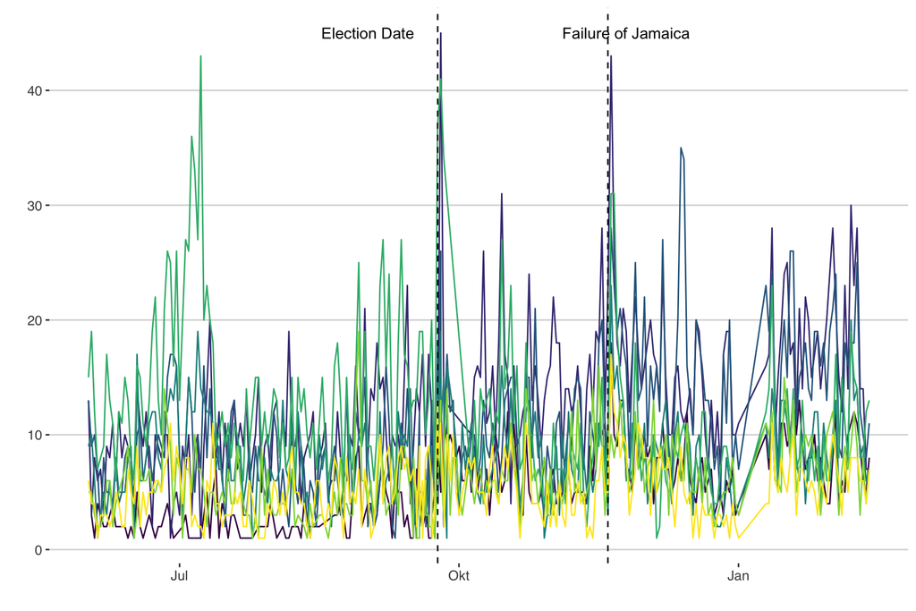

## Number of words (article length)

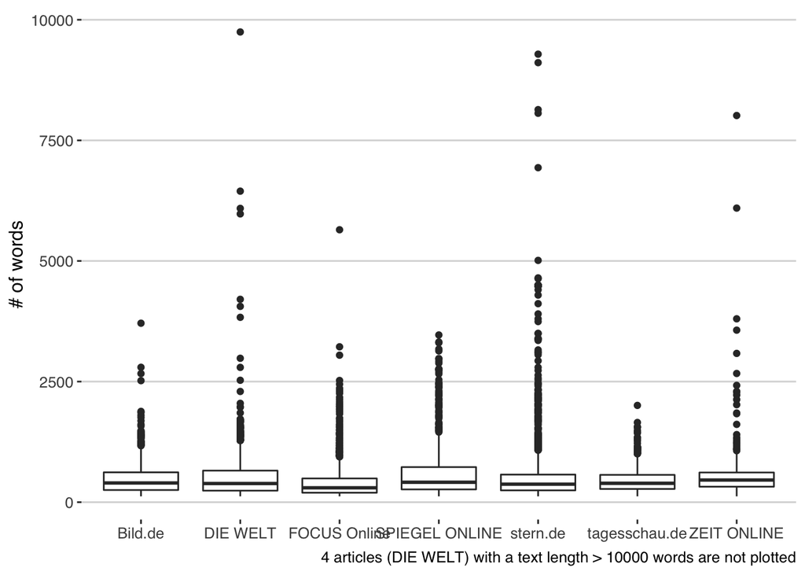

## Wordclouds

### Before pre-processing:

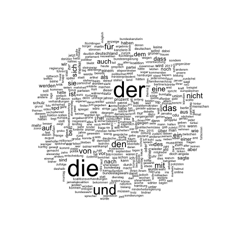

### Pre-processed Data:

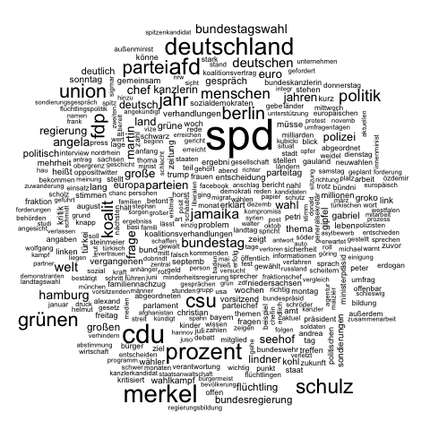

## Visibility

In order to get a deeper understanding of the extent to which the newspapers report about parties, the mention of the individual parties in the articles can be considered. Indeed, the visibility of an entity is a commonly used measure in communication literature [Eberl, 2017](https://journals.sagepub.com/doi/abs/10.1177/0093650215614364).

The visibility of a party $p$ in a newspaper $s$ is defined as the number of news articles published by the newspaper on that party (e.g. articles that mention the name of the party), normalised on the total amount of articles by that newspaper in the corpus. A party is treated as visible in an article if the party itself is mentioned in an article (if an article contains the word “SPD”, “CDU”/“CSU/Union”,“FDP”,“Grüne”,“AfD” or “Linke”)

[interactive chart not shown]

### Deviation from average visibility

Due to political relevance, not all potential parties recieve equal amounts of coverage in media. However, these factors should infuence all media outlets equally. To what extent does the visibility of a party in a medium differ from the average visibility in the media? To calculate the relative visibility, I estimate the deviation of the visibility of a party in one medium from the average visibility of that party over all news paper.

[interactive chart not shown]